# curvana: a comprehensive R package for analyzing atomic force microscopy force–distance curves

### Rupture/adhesion distance

For rupture events, which are in negative-force excursions, the function can be set to scan from right to left and identify the first point where the curve dips below the negative noise threshold, which in turn indicates the end of significant adhesion.

Specifically, the function scans the curve from right to left, `x_direction = "left"`, while excluding the baseline region defined by `baseline_span`, to look for the first negative-force excursion, `y_direction = "negative"`, with at least 3 consecutive points below the threshold, `min_consecutive = 3`.

```r
res.rupturedis = analyze_a_curve_interaction_distance(example1.transformed,
                                                      y_direction = "negative",
                                                      x_direction = "left",
                                                      baseline_span = 200,
                                                      noiseBand_low = res.noise[['noiseBand_low']],
                                                      noiseBand_high = res.noise[['noiseBand_high']],
                                                      min_consecutive = 3
                                                      )

print(res.rupturedis)
```

```
##    distance   threshold
## 12.55671956 -0.02063768
```

To analyze rupture distance for all curves in an fdObj, we can use the wrapper function `analyze_curves_interaction_distance()` with the same parameters. The calculated rupture distance is recorded in a metadata column named `rupture_distance_nm`. Curves that fail transformation will have `NA` in this column.

```r
test2 = analyze_curves_interaction_distance(test2,
                                           useCurve = 'retract', # analyze retract curve
                                           y_direction = "negative", x_direction = "left",
                                           baseline_span = 'automatic', # use the baseline span values in metadata column "baseline_span_retract" for each curve
                                            min_consecutive = 3
                                            )
```

```
## Interaction distance analyzed for 101/101 curves (retract, rupture): 89 valid results.
```

```r
view_df(test2@metadata,'metadata with rupture length')
```

|  | filename | Number_of_datapoints_approach | Number_of_datapoints_retract | surface | region | spring_constant | sensitivity_V_nm_approach | baseline_V_approach | baseline_span_approach | sensitivity_V_nm_retract | baseline_V_retract | baseline_span_retract | noiseBand_low_nN_approach | noiseBand_high_nN_approach | noiseBand_low_nN_retract | noiseBand_high_nN_retract | adhesive_force_nN_approach | adhesive_sep_nm_approach | adhesive_force_nN_retract | adhesive_sep_nm_retract | adhesive_energy_aJ_approach | repulsive_energy_aJ_approach | adhesive_energy_aJ_retract | repulsive_energy_aJ_retract | rupture_distance_nm_retract | rupture_threshold_nN_retract |
| --- | --- | --- | --- | --- | --- | --- | --- | --- | --- | --- | --- | --- | --- | --- | --- | --- | --- | --- | --- | --- | --- | --- | --- | --- | --- | --- |
| F_1.spm-F4E1_ForceCurveIndex_0.spm | F_1.spm-F4E1_ForceCurveIndex_0.spm | 512 | 512 | Group_A | 1 | 0.08 | 0.01953175268173134 | -0.22915625 | 300 | 0.0185355755023641 | -0.2324710416666667 | 300 | -0.01932750256217852 | 0.01702356185940229 | -0.01469156793280754 | 0.01983662893479835 | 0.3782302653724345 | 0.659649033612661 | 6.906303861476515 | -1.179719620789371 | 1.52126866074192 | 0.1419465887645222 | 302.5896719903102 | 0.1498346591159349 | 90.79111510625344 | -0.01469156793280754 |
| F_1.spm-F4E1_ForceCurveIndex_1.spm | F_1.spm-F4E1_ForceCurveIndex_1.spm | 512 | 512 | Group_A | 1 | 0.08 | 0.01919879781109477 | -0.2264658333333334 | 300 | 0.01851595098597184 | -0.2322664583333333 | 300 | -0.01785181221791217 | 0.01496274243279231 | -0.01937158580756028 | 0.01789358088697035 | 0.412147333973206 | 0.554440545163823 | 4.599206565077417 | 2.067224738593488 | 1.757585710250056 | 0.05905711714112136 | 148.0256565540194 | 0.06232472005157359 | 57.71496392656269 | -0.01937158580756028 |
| F_1.spm-F4E1_ForceCurveIndex_10.spm | F_1.spm-F4E1_ForceCurveIndex_10.spm | 512 | 512 | Group_A | 1 | 0.08 | 0.01938341015922519 | -0.2568625 | 300 | 0.01848164144586605 | -0.261550625 | 300 | -0.01294921780729807 | 0.0138778469727618 | -0.01709534301514488 | 0.01536930585045726 | 0.2714176688613339 | -0.01021749154837615 | 7.916285489497233 | -1.04299005306288 | 0.8493891001364311 | 0.2108330117525492 | 395.1555769889826 | 0.09551617824244871 | 98.66518090899976 | -0.01709534301514488 |
| F_1.spm-F4E1_ForceCurveIndex_2.spm | F_1.spm-F4E1_ForceCurveIndex_2.spm | 512 | 512 | Group_A | 1 | 0.08 | 0.0184777721502696 | -0.2240177083333333 | 300 | 0.01877256318423071 | -0.2283635416666667 | 300 | -0.01561786404694485 | 0.01847715535672323 | -0.01656229166019496 | 0.01220309294394968 | 0.382545215724516 | 0.2712855694773326 | 5.821843058622542 | 0.2519295723933936 | 1.569244779401465 | 0.1827608201429701 | 221.4383955617098 | 0.3573062487541803 | 72.33173973768058 | -0.01656229166019496 |
| F_1.spm-F4E1_ForceCurveIndex_3.spm | F_1.spm-F4E1_ForceCurveIndex_3.spm | 512 | 512 | Group_A | 1 | 0.08 | 0.01864995710405837 | -0.2190122916666667 | 300 | 0.01876507451418484 | -0.2244814583333334 | 300 | -0.01174354801164691 | 0.01613855365210664 | -0.02032943344003056 | 0.01697390897253812 | 0.321663831889524 | 0.1087491306858839 | 8.533485076879776 | 0.1886820468661483 | 1.323165096551329 | 0.1939456927756851 | 475.3704726044384 | 0.07745105180938809 | 93.31253495154075 | -0.02032943344003056 |
| F_1.spm-F4E1_ForceCurveIndex_4.spm | F_1.spm-F4E1_ForceCurveIndex_4.spm | 512 | 512 | Group_A | 1 | 0.08 | 0.01958435316127593 | -0.2118975 | 300 | 0.01860802118930836 | -0.2193322916666667 | 300 | -0.01114154744877893 | 0.009793532542052254 | -0.01523088692684369 | 0.01432625912348507 | 0.2807445287941179 | 0.7876340354183662 | 8.998991078260417 | -0.9179925102257585 | 1.084715402761747 | 0.1100549495946918 | 512.68500103552 | 0.1053258910889671 | 105.1930173381948 | -0.01523088692684369 |
| F_1.spm-F4E1_ForceCurveIndex_5.spm | F_1.spm-F4E1_ForceCurveIndex_5.spm | 512 | 512 | Group_A | 1 | 0.08 | 0.01974969378924028 | -0.208544375 | 300 | 0.01855071135453553 | -0.2122558333333334 | 300 | -0.01501035930802666 | 0.0123318367666383 | -0.01075610145184799 | 0.01296266553184631 | 0.4433714311444439 | 0.9714866744980615 | 6.964128267876226 | -2.583268136373974 | 2.130108121234758 | 0.1677814338697816 | 298.1984910103744 | 0.1684038600592396 | 81.2462944790333 | -0.01075610145184799 |
| F_1.spm-F4E1_ForceCurveIndex_6.spm | F_1.spm-F4E1_ForceCurveIndex_6.spm | 512 | 512 | Group_A | 1 | 0.08 | 0.0190822422605573 | -0.2024758333333334 | 300 | 0.01838381145447972 | -0.2084514583333334 | 300 | -0.01529869128308656 | 0.01457201218126378 | -0.02088159652223743 | 0.01556351180902406 | 0.2259657578211357 | 0.8605916638243127 | 7.653140029297319 | -1.199673488263684 | 0.7174156161736311 | 0.2225469546352301 | 370.3267847904337 | 0.120046537620812 | 82.8203925487932 | -0.02088159652223743 |
| F_1.spm-F4E1_ForceCurveIndex_7.spm | F_1.spm-F4E1_ForceCurveIndex_7.spm | 512 | 512 | Group_A | 1 | 0.08 | 0.01926291314275661 | -0.1937797916666667 | 300 | 0.01838945375728929 | -0.201685625 | 300 | -0.01389284500653511 | 0.01362116578052459 | -0.01496238026596818 | 0.01548985651012559 | 0.2651528680430804 | 0.09308986648792139 | 8.10492535380073 | -1.925612474940749 | 0.9628588646084485 | 0.07162324765475368 | 408.2712373597486 | 0.1327429563330381 | 100.4156863755885 | -0.01496238026596818 |
| F_1.spm-F4E1_ForceCurveIndex_8.spm | F_1.spm-F4E1_ForceCurveIndex_8.spm | 512 | 512 | Group_A | 1 | 0.08 | 0.01846043987251427 | -0.2695852083333334 | 300 | 0.01815902925417498 | -0.2802514583333334 | 300 | -0.01696510676322667 | 0.01607852622778498 | -0.01871704310709173 | 0.02093265346655435 | 0.2287693772465967 | -0.1378864240375388 | 6.805423439962841 | -2.422922523180731 | 0.7368991794281446 | 0.1441013868813086 | 287.7469247247797 | 0.1869763214766936 | 59.19660875926827 | -0.01871704310709173 |

[output cut: 91 more lines]

### Repulsive distance

For repulsive interactions, which are positive-force excursions, the function can be set to scan from left to right and identify the last point before the curve crosses the positive noise threshold and enters the noise band from the repulsive region, which marks the end of significant repulsion.

Specifically, the function scans the curve from left to right, `x_direction = "right"`, up to the beginning of the baseline region, as defined by `baseline_span`. It identifies the last data point where the curve first crosses the positive noise threshold, `y_direction = "positive"`, entering the noise band from the repulsive-force region. Because the curve is expected to begin in the repulsive region, `min_consecutive` is set to 1, meaning that a single point above the positive noise threshold is sufficient to mark the start of the repulsive region.

```r
res.repuldis = analyze_a_curve_interaction_distance(example1.transformed,
                                                      y_direction = "positive",
                                                      x_direction = "right",
                                                      baseline_span = 200,
                                                      noiseBand_low = res.noise[['noiseBand_low']],
                                                      noiseBand_high = res.noise[['noiseBand_high']],
                                                      min_consecutive = 1
                                                      )

print(res.repuldis)
```

```
##   distance  threshold
## 0.00000000 0.03072579
```

To analyze repulsive distance for all curves in an fdObj, we can use the wrapper function `analyze_curves_interaction_distance()` with the same parameters. The calculated repulsive distance is recorded in a metadata column named `repulsive_distance_nm`. Curves that fail transformation will have `NA` in this column.

```r
test2 = analyze_curves_interaction_distance(test2,
                                           useCurve = 'approach', # analyze approach curve
                                           y_direction = "positive", x_direction = "right",
                                           baseline_span = 'automatic', # use the baseline span values in metadata column "baseline_span_approach" for each curve
                                           min_consecutive = 1
                                          )
```

```
## Interaction distance analyzed for 101/101 curves (approach, repulsive): 94 valid results.
```

```r
view_df(test2@metadata,'metadata with repulsive distance')
```

|  | filename | Number_of_datapoints_approach | Number_of_datapoints_retract | surface | region | spring_constant | sensitivity_V_nm_approach | baseline_V_approach | baseline_span_approach | sensitivity_V_nm_retract | baseline_V_retract | baseline_span_retract | noiseBand_low_nN_approach | noiseBand_high_nN_approach | noiseBand_low_nN_retract | noiseBand_high_nN_retract | adhesive_force_nN_approach | adhesive_sep_nm_approach | adhesive_force_nN_retract | adhesive_sep_nm_retract | adhesive_energy_aJ_approach | repulsive_energy_aJ_approach | adhesive_energy_aJ_retract | repulsive_energy_aJ_retract | rupture_distance_nm_retract | rupture_threshold_nN_retract | repulsive_distance_nm_approach | repulsive_threshold_nN_approach |
| --- | --- | --- | --- | --- | --- | --- | --- | --- | --- | --- | --- | --- | --- | --- | --- | --- | --- | --- | --- | --- | --- | --- | --- | --- | --- | --- | --- | --- |
| F_1.spm-F4E1_ForceCurveIndex_0.spm | F_1.spm-F4E1_ForceCurveIndex_0.spm | 512 | 512 | Group_A | 1 | 0.08 | 0.01953175268173134 | -0.22915625 | 300 | 0.0185355755023641 | -0.2324710416666667 | 300 | -0.01932750256217852 | 0.01702356185940229 | -0.01469156793280754 | 0.01983662893479835 | 0.3782302653724345 | 0.659649033612661 | 6.906303861476515 | -1.179719620789371 | 1.52126866074192 | 0.1419465887645222 | 302.5896719903102 | 0.1498346591159349 | 90.79111510625344 | -0.01469156793280754 | 0 | 0.01702356185940229 |
| F_1.spm-F4E1_ForceCurveIndex_1.spm | F_1.spm-F4E1_ForceCurveIndex_1.spm | 512 | 512 | Group_A | 1 | 0.08 | 0.01919879781109477 | -0.2264658333333334 | 300 | 0.01851595098597184 | -0.2322664583333333 | 300 | -0.01785181221791217 | 0.01496274243279231 | -0.01937158580756028 | 0.01789358088697035 | 0.412147333973206 | 0.554440545163823 | 4.599206565077417 | 2.067224738593488 | 1.757585710250056 | 0.05905711714112136 | 148.0256565540194 | 0.06232472005157359 | 57.71496392656269 | -0.01937158580756028 | 0 | 0.01496274243279231 |
| F_1.spm-F4E1_ForceCurveIndex_10.spm | F_1.spm-F4E1_ForceCurveIndex_10.spm | 512 | 512 | Group_A | 1 | 0.08 | 0.01938341015922519 | -0.2568625 | 300 | 0.01848164144586605 | -0.261550625 | 300 | -0.01294921780729807 | 0.0138778469727618 | -0.01709534301514488 | 0.01536930585045726 | 0.2714176688613339 | -0.01021749154837615 | 7.916285489497233 | -1.04299005306288 | 0.8493891001364311 | 0.2108330117525492 | 395.1555769889826 | 0.09551617824244871 | 98.66518090899976 | -0.01709534301514488 | 0.03020646167193397 | 0.0138778469727618 |
| F_1.spm-F4E1_ForceCurveIndex_2.spm | F_1.spm-F4E1_ForceCurveIndex_2.spm | 512 | 512 | Group_A | 1 | 0.08 | 0.0184777721502696 | -0.2240177083333333 | 300 | 0.01877256318423071 | -0.2283635416666667 | 300 | -0.01561786404694485 | 0.01847715535672323 | -0.01656229166019496 | 0.01220309294394968 | 0.382545215724516 | 0.2712855694773326 | 5.821843058622542 | 0.2519295723933936 | 1.569244779401465 | 0.1827608201429701 | 221.4383955617098 | 0.3573062487541803 | 72.33173973768058 | -0.01656229166019496 | 0 | 0.01847715535672323 |
| F_1.spm-F4E1_ForceCurveIndex_3.spm | F_1.spm-F4E1_ForceCurveIndex_3.spm | 512 | 512 | Group_A | 1 | 0.08 | 0.01864995710405837 | -0.2190122916666667 | 300 | 0.01876507451418484 | -0.2244814583333334 | 300 | -0.01174354801164691 | 0.01613855365210664 | -0.02032943344003056 | 0.01697390897253812 | 0.321663831889524 | 0.1087491306858839 | 8.533485076879776 | 0.1886820468661483 | 1.323165096551329 | 0.1939456927756851 | 475.3704726044384 | 0.07745105180938809 | 93.31253495154075 | -0.02032943344003056 | 0.01147292585898607 | 0.01613855365210664 |
| F_1.spm-F4E1_ForceCurveIndex_4.spm | F_1.spm-F4E1_ForceCurveIndex_4.spm | 512 | 512 | Group_A | 1 | 0.08 | 0.01958435316127593 | -0.2118975 | 300 | 0.01860802118930836 | -0.2193322916666667 | 300 | -0.01114154744877893 | 0.009793532542052254 | -0.01523088692684369 | 0.01432625912348507 | 0.2807445287941179 | 0.7876340354183662 | 8.998991078260417 | -0.9179925102257585 | 1.084715402761747 | 0.1100549495946918 | 512.68500103552 | 0.1053258910889671 | 105.1930173381948 | -0.01523088692684369 | 0 | 0.009793532542052254 |
| F_1.spm-F4E1_ForceCurveIndex_5.spm | F_1.spm-F4E1_ForceCurveIndex_5.spm | 512 | 512 | Group_A | 1 | 0.08 | 0.01974969378924028 | -0.208544375 | 300 | 0.01855071135453553 | -0.2122558333333334 | 300 | -0.01501035930802666 | 0.0123318367666383 | -0.01075610145184799 | 0.01296266553184631 | 0.4433714311444439 | 0.9714866744980615 | 6.964128267876226 | -2.583268136373974 | 2.130108121234758 | 0.1677814338697816 | 298.1984910103744 | 0.1684038600592396 | 81.2462944790333 | -0.01075610145184799 | 0 | 0.0123318367666383 |
| F_1.spm-F4E1_ForceCurveIndex_6.spm | F_1.spm-F4E1_ForceCurveIndex_6.spm | 512 | 512 | Group_A | 1 | 0.08 | 0.0190822422605573 | -0.2024758333333334 | 300 | 0.01838381145447972 | -0.2084514583333334 | 300 | -0.01529869128308656 | 0.01457201218126378 | -0.02088159652223743 | 0.01556351180902406 | 0.2259657578211357 | 0.8605916638243127 | 7.653140029297319 | -1.199673488263684 | 0.7174156161736311 | 0.2225469546352301 | 370.3267847904337 | 0.120046537620812 | 82.8203925487932 | -0.02088159652223743 | 0 | 0.01457201218126378 |
| F_1.spm-F4E1_ForceCurveIndex_7.spm | F_1.spm-F4E1_ForceCurveIndex_7.spm | 512 | 512 | Group_A | 1 | 0.08 | 0.01926291314275661 | -0.1937797916666667 | 300 | 0.01838945375728929 | -0.201685625 | 300 | -0.01389284500653511 | 0.01362116578052459 | -0.01496238026596818 | 0.01548985651012559 | 0.2651528680430804 | 0.09308986648792139 | 8.10492535380073 | -1.925612474940749 | 0.9628588646084485 | 0.07162324765475368 | 408.2712373597486 | 0.1327429563330381 | 100.4156863755885 | -0.01496238026596818 | 0 | 0.01362116578052459 |
| F_1.spm-F4E1_ForceCurveIndex_8.spm | F_1.spm-F4E1_ForceCurveIndex_8.spm | 512 | 512 | Group_A | 1 | 0.08 | 0.01846043987251427 | -0.2695852083333334 | 300 | 0.01815902925417498 | -0.2802514583333334 | 300 | -0.01696510676322667 | 0.01607852622778498 | -0.01871704310709173 | 0.02093265346655435 | 0.2287693772465967 | -0.1378864240375388 | 6.805423439962841 | -2.422922523180731 | 0.7368991794281446 | 0.1441013868813086 | 287.7469247247797 | 0.1869763214766936 | 59.19660875926827 | -0.01871704310709173 | 0 | 0.01607852622778498 |

[output cut: 91 more lines]

## All-in-one analytical wrapper

You can run all analytical-metric steps described above in one call using `analyze_curves_all_analytical_metrics()`. This function combines the analyses above into a single streamlined workflow, allowing you to compute noise levels, adhesive forces, interaction energies, and interaction distances for all curves in an fdObj with one command. By setting the appropriate toggles, you can customize which metrics to calculate and how to apply noise thresholds, providing a comprehensive analysis of your AFM force spectroscopy data in a single step.

```r
test = analyze_curves_all_analytical_metrics(
  test, # the object
  useCurve = "both", # run analysis for both approach and retract

  # noise band parameters
  noise_baseline_span = "automatic", # use the baseline section previously defined in curve transformation for noise band calculation
  noise_threshold_method = "quantile", # use quantile method to define the noise band
  noise_quantile_low = 0.00, # define the lower end of noise band as minimum y value of the baseline section
  noise_quantile_high = 1, # define the upper end of noise band as maximum y value of the baseline section
  noise_multiplier = 1, # multiply the noise band by 1 to directly use the min-max range of the force in baseline region without further scaling.

  # adhesive force
  analyze_adhesive_force = TRUE, # whether to analyze adhesive force

  # adhesive energy and repulsive energy
  analyze_energy = TRUE, # whether to analyze interaction energy (repulsive and adhesive)

  # rupture (adhesive) distance
  analyze_rupture_distance = TRUE, # whether to analyze adhesive/rupture distance
  analyze_rupture_distance_baseline_span = "automatic", # use the baseline section previously defined in curve transformation for rupture distance analysis
  analyze_rupture_distance_x_direction = "left", # scan from right to left to find the first data point at which a curve enters the adhesive region from the noise band region
  analyze_rupture_distance_min_consecutive = 3, # to reduce false positives from random fluctuations, require at least 3 consecutive points below the lower noise-band threshold for classifying the curve as entering the adhesive region.

  # repulsive distance
  analyze_repulsive_distance = TRUE, # whether to analyze repulsive distance
  analyze_repulsive_distance_baseline_span = "automatic", # use the baseline section previously defined in curve transformation for repulsive distance analysis
  analyze_repulsive_distance_x_direction = "right", # scan from left to right to find the last data point before a curve first enters the noise band region from the repulsive region
  analyze_repulsive_distance_min_consecutive = 1 # because the curve is expected to start from the repulsive region, we set min_consecutive to 1, meaning that a single point above the positive noise threshold is sufficient to mark the start of the repulsive region.
)
```

```
## Analyzing approach curves ...
```

```
## Noise bands analyzed for 101 curves (approach): 94 valid results.
```

```
## Adhesive force analyzed for 101 curves: 94 with adhesion, 0 with no adhesion (0), 7 not analyzed (NA).
```

```
## Energy analyzed for 101 curves (approach): 7 NA adhesive, 7 NA repulsive (units = aJ).
```

```
## Interaction distance analyzed for 101/101 curves (approach, rupture): 64 valid results.
```

```
## Interaction distance analyzed for 101/101 curves (approach, repulsive): 94 valid results.
```

```
## Analyzing retract curves ...
```

```
## Noise bands analyzed for 101 curves (retract): 92 valid results.
```

```
## Adhesive force analyzed for 101 curves: 92 with adhesion, 0 with no adhesion (0), 9 not analyzed (NA).
```

```
## Energy analyzed for 101 curves (retract): 9 NA adhesive, 9 NA repulsive (units = aJ).
```

```
## Interaction distance analyzed for 101/101 curves (retract, rupture): 89 valid results.
```

```
## Interaction distance analyzed for 101/101 curves (retract, repulsive): 92 valid results.
```

# Visualization of analytical metrics

`plot_a_curve_metrics()` can be used to visualize the calculated analytical metrics for a single curve.

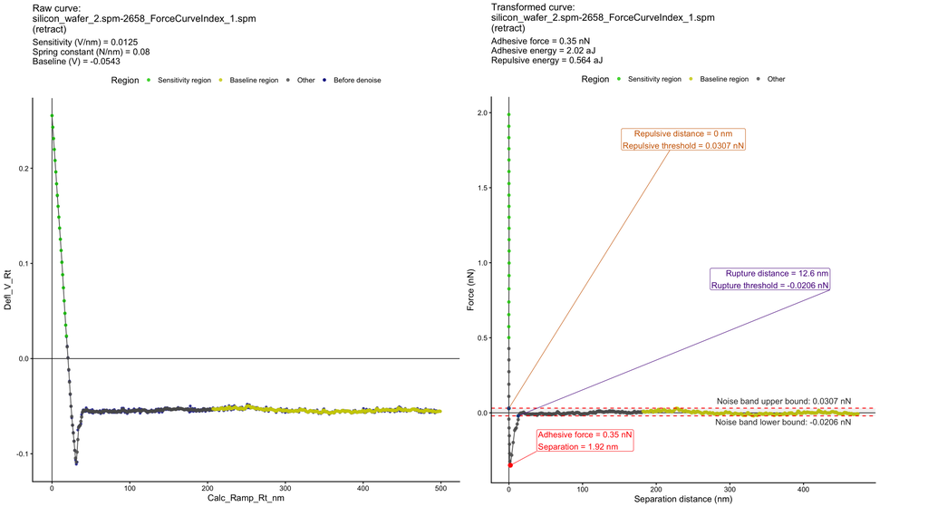

```r
plot_a_curve_metrics(
  fdobj = test,
  curve_name = example1.name,
  useCurve = "retract", # which curve to plot, can be "approach" or "retract".
  plot_raw = T, # whether to plot the raw curve together with the transformed curve.
  base_size = 15,
  annotation_text_size = 5
)
```

# Save all raw and transformed curves with analytical metrics annotated (optional)

```r
plot_all_curve_metrics(
  fdobj = test, # the fdObj to plot
  useCurve = "retract", # plot the retract curve
  plot_raw = T, # whether to plot the raw curve
  destination_folder = '../test_plot_metrics_denoised', # the path to save the plots
  format = 'png', width = 18, height = 9, # plot format and dimensions
  threads = 8 # number of threads to use for parallel processing (set to 8 to use 8 cores, which will significantly speed up the plotting process for a large dataset
)
plot_all_curve_metrics(
  fdobj = test, # the fdObj to plot
  useCurve = "approach", # plot the approach curve
  plot_raw = T, # whether to plot the raw curve
  destination_folder = '../test_plot_metrics_denoised', # the path to save the plots
  format = 'png', width = 18, height = 9, # plot format and dimensions
  threads = 8 # number of threads to use for parallel processing (set to 8 to use 8 cores, which will significantly speed up the plotting process for a large dataset
)
```

# Summary statistics of analytical metrics

## PCA biplot of selected metrics

Dimensionality reduction is first used to visualize the overall pattern of how curves cluster based on their analytical metrics. The function `plot_pca_biplot()` performs principal component analysis (PCA) on the selected metrics and plots sample scores in PCA space, colored by a specified metadata variable such as surface type. The function also plots feature loadings as arrows, indicating how each metric contributes to the principal components and the clustering pattern of samples.

```
## Dropped 17 row(s) with missing/non-finite feature values or missing color group.
```

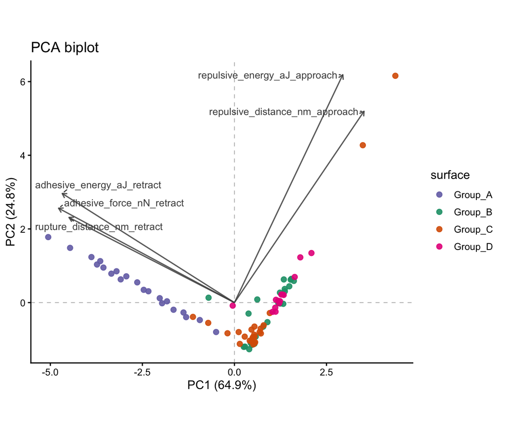

```r
pca_features <- c(
  "adhesive_force_nN_retract",
  "adhesive_energy_aJ_retract",
  "rupture_distance_nm_retract",
  "repulsive_energy_aJ_approach",
  "repulsive_distance_nm_approach"
)

plot_pca_biplot(
  df = test@metadata,
  include_columns = pca_features,
  color_by = "surface",
  color_map = c(
    Group_B = "#1b9e77",
    Group_C = "#d95f02",
    Group_A = "#7570b3",
    Group_D = "#e7298a"
  ),
  arrow_scale = 1.1,
  show_feature_labels = TRUE
)
```

## Scaled feature heatmap with sample annotations

```
## Dropped 17 row(s) with missing/non-numeric feature values.
```

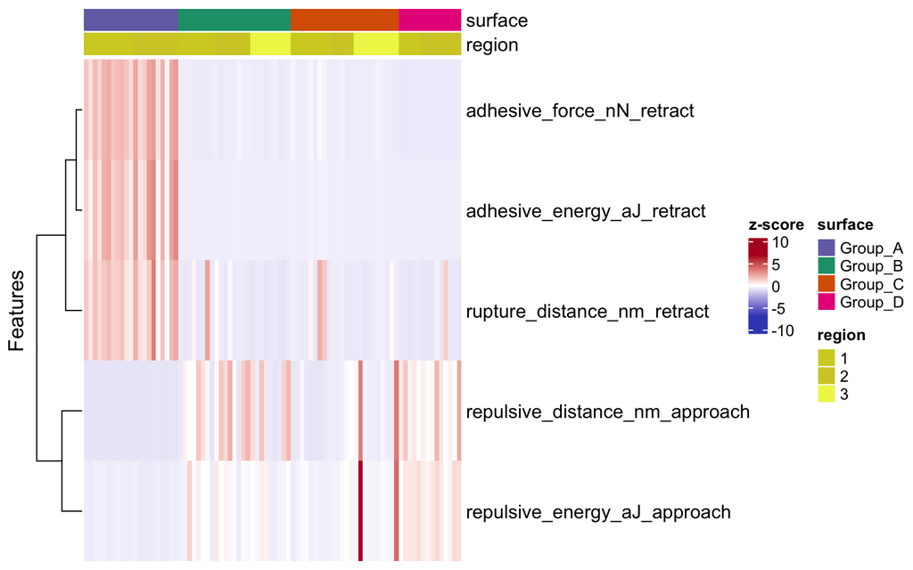

```r
  plot_complex_heatmap(
    df = test@metadata,
    include_columns = pca_features,
    annotate_columns = c("surface", "region"),
    annotation_colors = list(
      surface = c(
        Group_B = "#1b9e77",
        Group_C = "#d95f02",
        Group_A = "#7570b3",
        Group_D = "#e7298a"
      )
    ),
    cluster_rows = TRUE,
    cluster_columns = FALSE,
    show_row_dend = TRUE,
    show_column_dend = FALSE,
    heatmap_name = "z-score",
    show_column_names = FALSE
  )
```

## Violin plot of selected metrics by surface

`plot_metric_violin()` can be used to visualize the distribution of selected metrics across different groups. Here, we plot violin plots for adhesive force, adhesive energy, and rupture distance from the retract curves, as well as repulsive energy and repulsive distance from the approach curves. The option `show_whisker_box = TRUE` displays the median and interquartile range of each distribution.

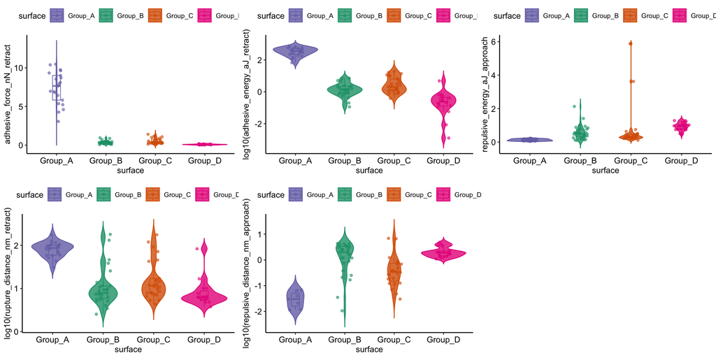

```r
f1 = plot_metric_violin(test@metadata, metric_name = "adhesive_force_nN_retract", group_by = "surface", color_map = c(Group_B = "#1b9e77", Group_C = "#d95f02", Group_A = "#7570b3", Group_D = "#e7298a"),
show_whisker_box = T)
f2 = plot_metric_violin(test@metadata, metric_name = "adhesive_energy_aJ_retract",log10=T,  group_by = "surface", color_map = c(Group_B = "#1b9e77", Group_C = "#d95f02", Group_A = "#7570b3", Group_D = "#e7298a"),
show_whisker_box = T)
f3 = plot_metric_violin(test@metadata, metric_name = "repulsive_energy_aJ_approach", group_by = "surface", color_map = c(Group_B = "#1b9e77", Group_C = "#d95f02", Group_A = "#7570b3", Group_D = "#e7298a"),
show_whisker_box = T)
f4 = plot_metric_violin(test@metadata, metric_name = "rupture_distance_nm_retract", log10=T, group_by = "surface", color_map = c(Group_B = "#1b9e77", Group_C = "#d95f02", Group_A = "#7570b3", Group_D = "#e7298a"),
show_whisker_box = T)
f5 = plot_metric_violin(test@metadata, metric_name = "repulsive_distance_nm_approach", log10=T, group_by = "surface", color_map = c(Group_B = "#1b9e77", Group_C = "#d95f02", Group_A = "#7570b3", Group_D = "#e7298a"),
show_whisker_box = T)

plot_grid(f1,f2,f3,f4,f5, nrow = 2)
```

## Violin plot with statistical annotations

`plot_metric_violin()` also has options to perform statistical tests and annotate significance on the plot. Here, we perform a Kruskal-Wallis test to compare adhesive force across different groups, followed by pairwise Wilcoxon tests for post hoc analysis. The p-values are reported.

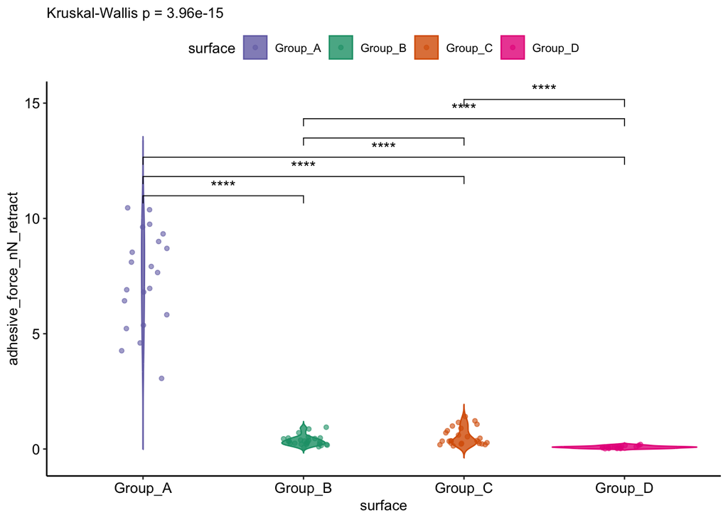

```r
plot_metric_violin(
  df = test@metadata,
  metric_name = "adhesive_force_nN_retract",
  group_by = "surface",
  color_by = "surface",
  color_map = c(
    Group_B = "#1b9e77",
    Group_C = "#d95f02",
    Group_A = "#7570b3",
    Group_D = "#e7298a"
  ),
  global_test = "kruskal",
  pairwise_test = "wilcox"
)
```

The function also allows users to specify which pairwise comparisons to perform so that only relevant comparisons are made and the plot is not overcrowded with significance annotations. Here, we compare Group_A with each of the other three groups.

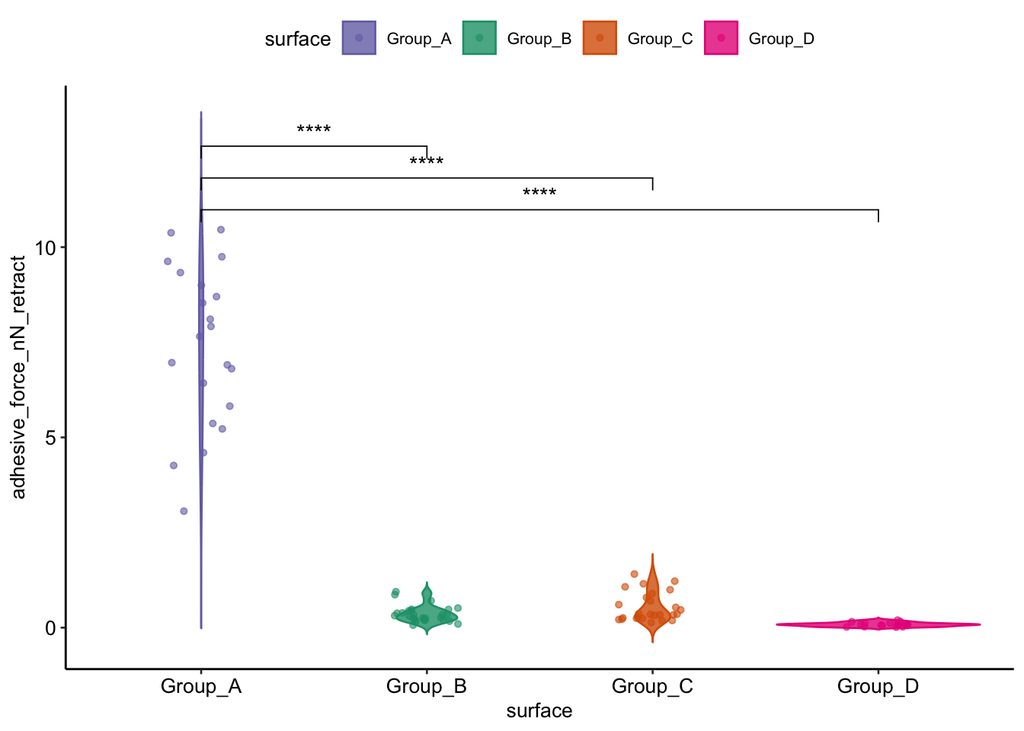

```r
plot_metric_violin(
  df = test@metadata,
  metric_name = "adhesive_force_nN_retract",
  group_by = "surface",
  color_by = "surface",
  color_map = c(
    Group_B = "#1b9e77",
    Group_C = "#d95f02",
    Group_A = "#7570b3",
    Group_D = "#e7298a"
  ),
  global_test = "none", # do not perform global test, only do pairwise comparisons
  pairwise_test = "wilcox",
  pairwise_comparisons = list(
    c("Group_A", "Group_D"),
    c("Group_A", "Group_C"),
    c("Group_A", "Group_B")
  )
)
```